# project_ess_final

Jeremy Knox

12/8/2018

Libraries and Data Frames:

Task 1: Climate Change Opinions (Yale Program on Climate Change Commu- nication)

```r
#---- 2 ----#
# correlation matrix
sapply(task1, class)
```

```
 GeoName    happening    consensus      discuss  mediaweekly
```

“character” “numeric” “numeric” “numeric” “numeric” bachelors poverty_rate coastline “numeric” “numeric” “character”

```r
subset_task1 = task1 %>% select(happening,consensus,discuss,mediaweekly,bachelors,poverty_rate)

cm = cor(subset_task1)
cm
```

```
          happening  consensus    discuss mediaweekly  bachelors
```

happening 1.0000000 0.9704873 0.8381948 0.5303038 0.7596682 consensus 0.9704873 1.0000000 0.8711812 0.6543700 0.8025877 discuss 0.8381948 0.8711812 1.0000000 0.7988550 0.6924601 mediaweekly 0.5303038 0.6543700 0.7988550 1.0000000 0.5385268 bachelors 0.7596682 0.8025877 0.6924601 0.5385268 1.0000000 poverty_rate -0.1557381 -0.2827506 -0.3346421 -0.4127744 -0.4366671 poverty_rate happening -0.1557381 consensus -0.2827506 discuss -0.3346421 mediaweekly -0.4127744 bachelors -0.4366671 poverty_rate 1.0000000

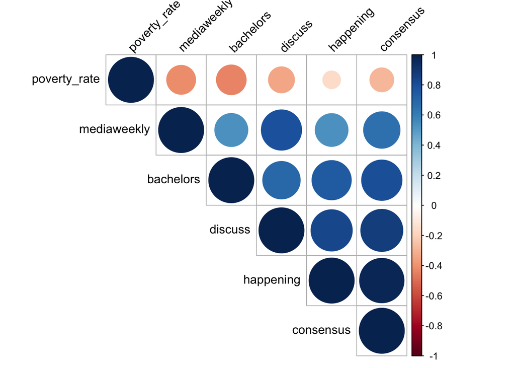

```r
corrplot(cm, type = "upper", order = "hclust",
         tl.col = "black", tl.srt = 45)
```

```r
# dependent "happening" is derived from a binomial variable with "yes", "no" or "dont know" responses. Then aggreagated at the state level and given as a percent of respondents who repsponded yes (is an estimate?).
lm = lm(data = task1, happening ~ bachelors + poverty_rate + coastline)
summary(lm) # NOT INCLUDED variables because of likely reverse causuality: "consensus", "discuss", "mediaweekly"
```

Call: lm(formula = happening ~ bachelors + poverty_rate + coastline, data = task1)

Residuals: Min 1Q Median 3Q Max -4.4251 -1.6052 0.1439 1.0285 7.5510

Coefficients: Estimate Std. Error t value Pr(>|t|)  
(Intercept) 43.77654 3.46548 12.632 < 2e-16 *bachelors 0.63196 0.07067 8.943 1.04e-11* poverty_rate 0.28470 0.13587 2.095 0.0415 *  
coastlineyes 3.48528 0.76154 4.577 3.46e-05 *** — Signif. codes: 0 ‘**’ 0.001 ’**’ 0.01 ’’ 0.05 ‘.’ 0.1 ‘’ 1

Residual standard error: 2.646 on 47 degrees of freedom Multiple R-squared: 0.7339, Adjusted R-squared: 0.717 F-statistic: 43.22 on 3 and 47 DF, p-value: 1.472e-13

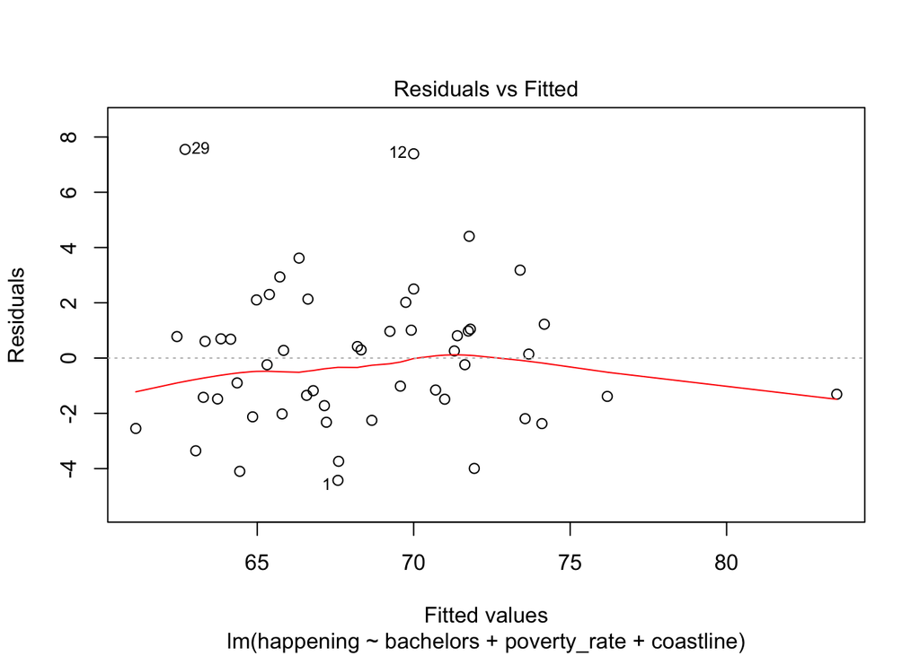

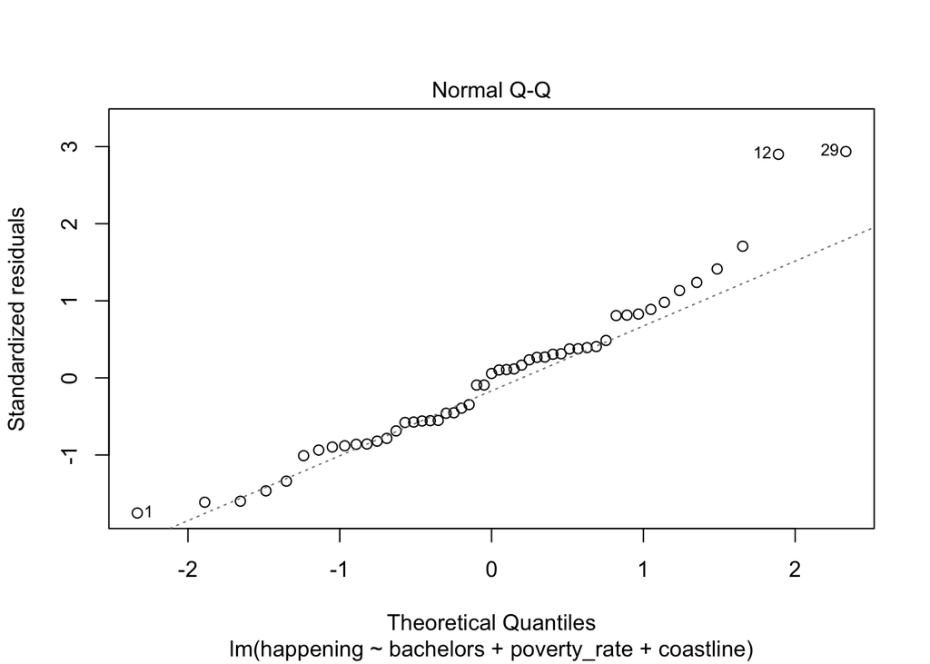

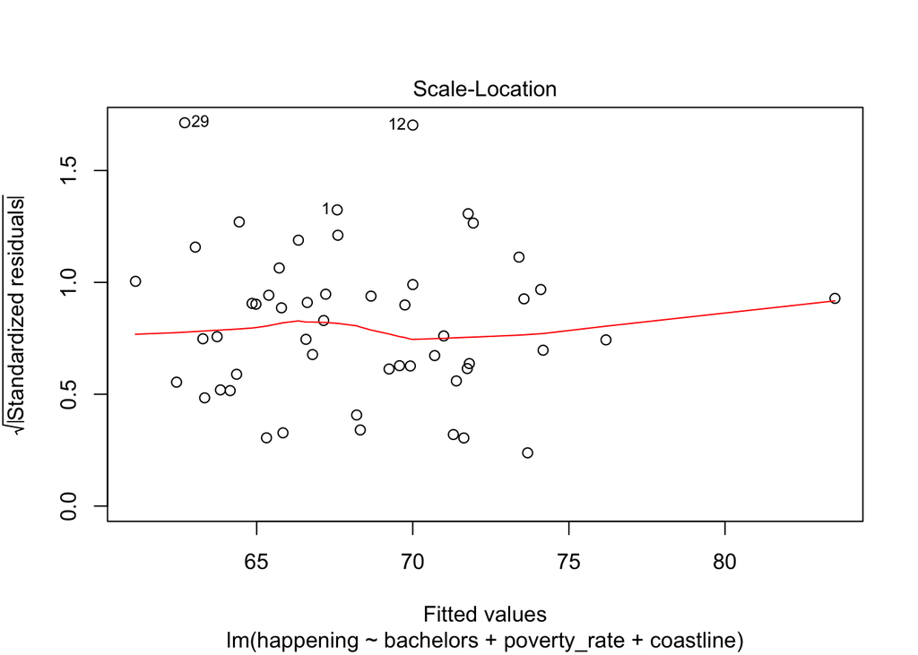

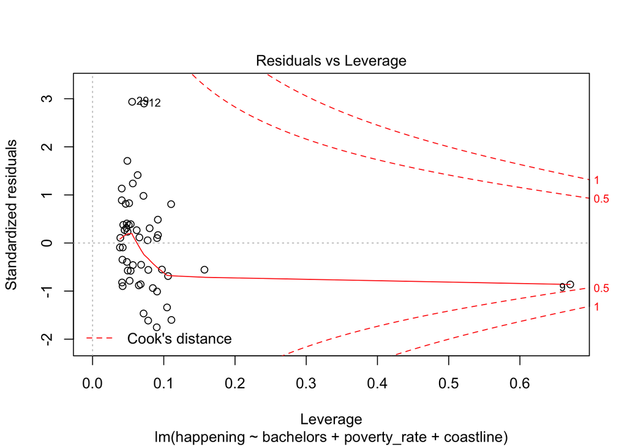

```r
plot(lm) # looks homoskedastic
```